```r
library(tidyverse)
library(caret)
```

```r
df <- readr::read_csv("fall2022_finalproject.csv", col_names = TRUE)
df <- df %>% mutate(y = boot::logit(output), outcome = ifelse(output < 0.33, 'event', 'non_event'), outcome = factor(outcome, levels = c("event", "non_event"))) %>%  glimpse()
```

```
## Rows: 1,252
## Columns: 13
## $ x1      <dbl> 0.025878, 0.030768, 0.019325, 0.306212, 0.031296, 0.031073, 0.…
## $ x2      <dbl> 0.255934, 0.261575, 0.020877, 0.033379, 0.259342, 0.027119, 0.…
## $ x3      <dbl> 0.492830, 0.498460, 0.258360, 0.255385, 0.264387, 0.260915, 0.…
## $ x4      <dbl> 0.012770, 0.055779, 0.012424, 0.056190, 0.056594, 0.055192, 0.…
## $ v1      <dbl> 0.275651, 0.343204, 4.998508, 5.090153, 5.031107, 9.977407, 0.…
## $ v2      <dbl> 0.033657, 0.027082, 0.030259, 0.052342, 0.517705, 0.532436, 1.…
## $ v3      <dbl> 1.166214, 1.260579, 1.298285, 1.322005, 1.368195, 1.298797, 1.…
## $ v4      <dbl> 0.408402, 0.664248, 0.412870, 0.652111, 0.533701, 0.857509, 0.…
## $ v5      <dbl> 0.525226, 2.866343, 0.409007, 0.861594, 6.451933, 0.958574, 0.…
## $ m       <chr> "A", "A", "A", "A", "A", "A", "A", "A", "A", "A", "A", "A", "A…
## $ output  <dbl> 0.786, 0.730, 0.996, 0.326, 0.735, 0.954, 0.969, 0.986, 0.874,…
## $ y       <dbl> 1.3009808, 0.9946226, 5.5174529, -0.7263327, 1.0201407, 3.0320…
## $ outcome <fct> non_event, non_event, non_event, event, non_event, non_event, …
```

```r
df_derived <- df %>% mutate(x5 = 1-x1-x2-x3-x4, w = x2 / (x3 + x4), z = (x1 + x2) / (x4 + x5), t = v1 * v2) %>%  glimpse()
```

```
## Rows: 1,252
## Columns: 17
## $ x1      <dbl> 0.025878, 0.030768, 0.019325, 0.306212, 0.031296, 0.031073, 0.…
## $ x2      <dbl> 0.255934, 0.261575, 0.020877, 0.033379, 0.259342, 0.027119, 0.…
## $ x3      <dbl> 0.492830, 0.498460, 0.258360, 0.255385, 0.264387, 0.260915, 0.…
## $ x4      <dbl> 0.012770, 0.055779, 0.012424, 0.056190, 0.056594, 0.055192, 0.…
## $ v1      <dbl> 0.275651, 0.343204, 4.998508, 5.090153, 5.031107, 9.977407, 0.…
## $ v2      <dbl> 0.033657, 0.027082, 0.030259, 0.052342, 0.517705, 0.532436, 1.…
## $ v3      <dbl> 1.166214, 1.260579, 1.298285, 1.322005, 1.368195, 1.298797, 1.…
## $ v4      <dbl> 0.408402, 0.664248, 0.412870, 0.652111, 0.533701, 0.857509, 0.…
## $ v5      <dbl> 0.525226, 2.866343, 0.409007, 0.861594, 6.451933, 0.958574, 0.…
## $ m       <chr> "A", "A", "A", "A", "A", "A", "A", "A", "A", "A", "A", "A", "A…
## $ output  <dbl> 0.786, 0.730, 0.996, 0.326, 0.735, 0.954, 0.969, 0.986, 0.874,…
## $ y       <dbl> 1.3009808, 0.9946226, 5.5174529, -0.7263327, 1.0201407, 3.0320…
## $ outcome <fct> non_event, non_event, non_event, event, non_event, non_event, …
## $ x5      <dbl> 0.212588, 0.153418, 0.689014, 0.348834, 0.388381, 0.625701, 0.…
## $ w       <dbl> 0.50619858, 0.47195344, 0.07709835, 0.10712990, 0.80796683, 0.…
## $ z       <dbl> 1.25050808, 1.39745312, 0.05731369, 0.83844661, 0.65315580, 0.…
## $ t       <dbl> 0.009277586, 0.009294651, 0.151249854, 0.266428788, 2.60462924…
```

```r
means_inputs <- colMeans(select(df_derived, -c(m, outcome)))
```

```r
viz_grid <- expand.grid(x1 = seq(0, 0.62, length.out = 101),
                        w = seq(0, 1, length.out = 6),
                        x2 = means_inputs['x2'],
                        x3 = means_inputs['x3'],
                        x4 = means_inputs['x4'],
                        v1 = means_inputs['v1'],
                        v2 = means_inputs['v2'],
                        v3 = means_inputs['v3'],
                        v4 = means_inputs['v4'],
                        v5 = means_inputs['v5'],
                        z = means_inputs['z'],
                        t = means_inputs['t'],
                        KEEP.OUT.ATTRS = FALSE,
                        stringsAsFactors = FALSE) %>%
  as.data.frame() %>% tibble::as_tibble()
```

# **Classification**

```r
df_bi <- df_derived %>% mutate(o =  ifelse(outcome == 'event', 1, 0))
```

## Linear models

First we use `glm()` to fit linear models.

### Base features

`mod_A, mod_B` and `mod_C` are models using *base features*.

All linear additive features:

```r
mod_A <- glm(o ~ x1 + x2 + x3 + x4 + v1 + v2 + v3 + v4 + v5 + m, family = binomial, data = df_bi)
```

Interaction of the categorical input with all continuous inputs:

```r
mod_B <- glm(o ~ m * (x1 + x2 + x3 + x4 + v1 + v2 + v3 + v4 + v5), family = binomial, data = df_bi)
```

All pair-wise interactions of the continuous inputs:

```r
mod_C <- glm(o ~ (x1 + x2 + x3 + x4 + v1 + v2 + v3 + v4 + v5) * (x1 + x2 + x3 + x4 + v1 + v2 + v3 + v4 + v5), family = binomial, data = df_bi)
```

### Expanded features

`mod_D, mod_E` and `mod_F` are models using *expanded features*.

Linear additive features:

```r
mod_D <- glm(o ~ x1 + x2 + x3 + x4 + v1 + v2 + v3 + v4 + v5 + m + w + z + t, family = binomial, data = df_bi)
```

Interaction of the categorical input with continuous features:

```r
mod_E <- glm(o ~ m * (x1 + x2 + x3 + x4 + v1 + v2 + v3 + v4 + v5 + w + z + t), family = binomial, data = df_bi)
```

Pair-wise interactions between the continuous features:

```r
mod_F <- glm(o ~ (x1 + x2 + x3 + x4 + v1 + v2 + v3 + v4 + v5 + w + z + t) * (x1 + x2 + x3 + x4 + v1 + v2 + v3 + v4 + v5 + w + z + t), family = binomial, data = df_bi)
```

### Linear basis functions

`mod_G, mod_H` and `mod_I` are models using *basis functions*.

Linear additive features of 3 degree-of-freedom natural spline from derived features:

```r
mod_G <- glm(o ~ splines::ns(x5, 3) + splines::ns(w, 3) + splines::ns(z, 3) + splines::ns(t, 3), family = binomial, data = df_bi)
```

The linear sum of interactions between `x1, x2, x3, w` and other continuous features with derived features having degree 2:

```r
mod_H <- glm(o ~ (x1 + x2 + x3 + w) * (x1 + x2 + x3 + w) + x4 + v1 + v2 + v3 + v4 + v5 + z + I(z^2) + t + I(t^2), family = binomial, data = df_bi)
```

The interaction between the categorical variable and linear sum of interactions between `x1, x2, x3, w` and other continuous features with derived features having freedom 3:

```r
mod_I <- glm(o ~ m * ((x1 + x2 + x3 + w) * (x1 + x2 + x3 + w) + x4 + v1 + v2 + v3 + v4 + v5 + splines::ns(z, 3) + splines::ns(t, 3) ), family = binomial, data = df_bi)
```

### Compare linear models

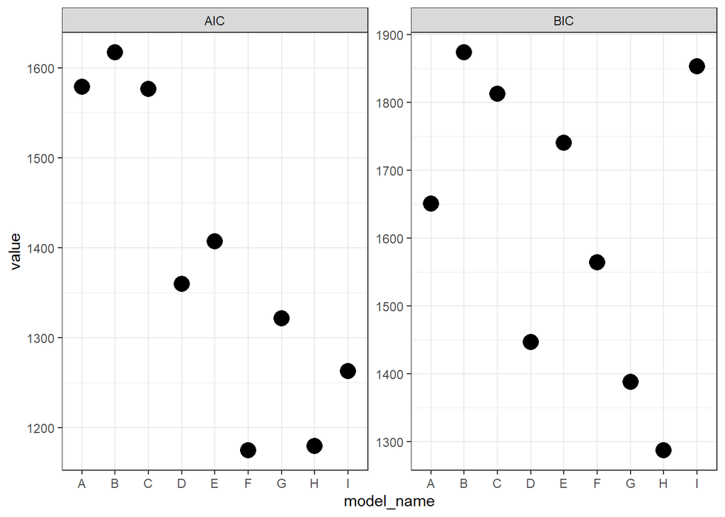

```r
extract_metrics_bi <- function(mod_object, mod_name)
{
  broom::glance(mod_object) %>%
    mutate(model_name = mod_name)
}
purrr::map2_dfr(list(mod_A, mod_B, mod_C, mod_D,
                                        mod_E, mod_F, mod_G, mod_H, mod_I),
                                   LETTERS[1:9],
                                   extract_metrics_bi) %>%
  select(model_name, AIC, BIC) %>%
  pivot_longer(c(AIC, BIC)) %>%
  ggplot(mapping = aes(x = model_name, y = value)) +
  geom_point(size = 5) +
  facet_wrap(~name, scales = 'free_y') +
  theme_bw()
```

The `mod_H` has the best BIC and a relatively low AIC, which means it is the best model. `mod_F` and `mod_G` are the sub-optimal models.

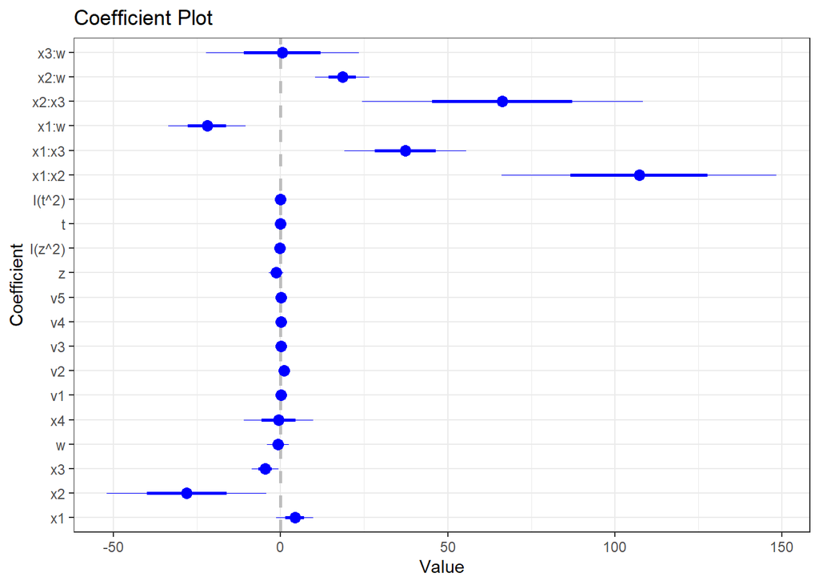

```r
mod_H %>%
  coefplot::coefplot(intercept = FALSE) +
  theme_bw()
```

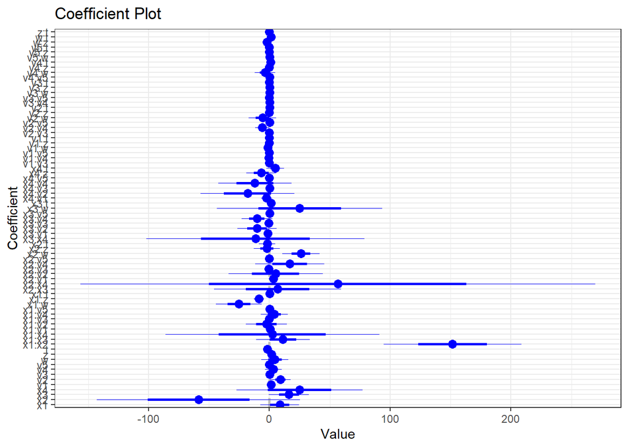

```r
mod_F %>%
  coefplot::coefplot(intercept = FALSE) +
  theme_bw()
```

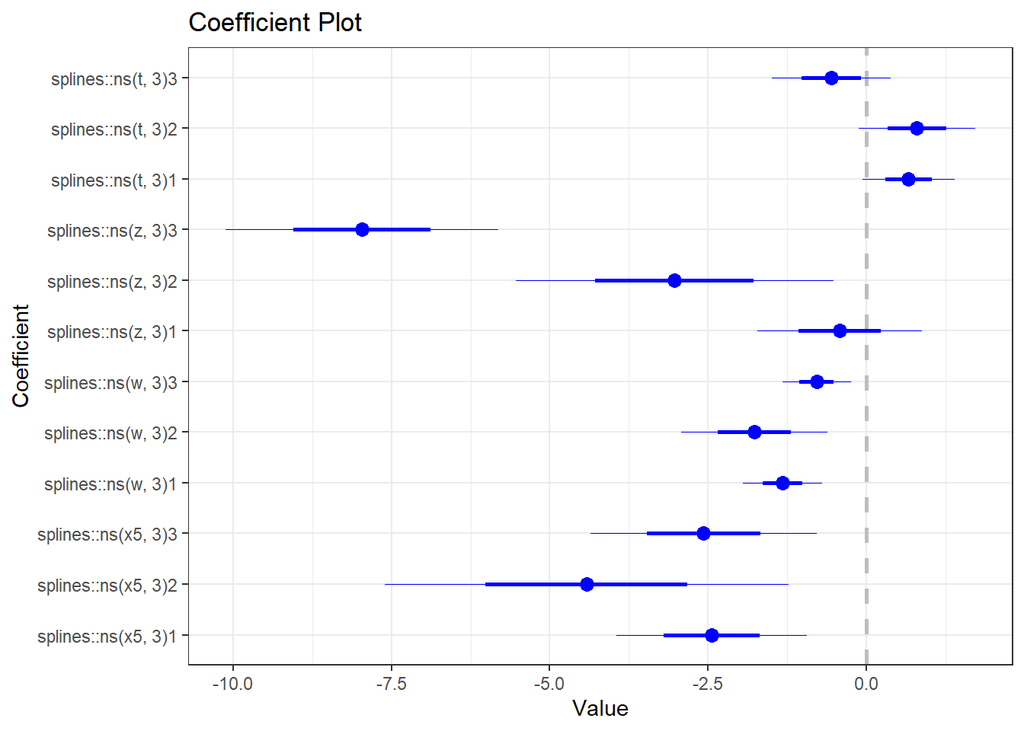

```r
mod_G %>%
  coefplot::coefplot(intercept = FALSE) +
  theme_bw()
```

```r
mod_H %>% summary()
```

```
##
## Call:
## glm(formula = o ~ (x1 + x2 + x3 + w) * (x1 + x2 + x3 + w) + x4 +
##     v1 + v2 + v3 + v4 + v5 + z + I(z^2) + t + I(t^2), family = binomial,
##     data = df_bi)
##
## Deviance Residuals:
##     Min       1Q   Median       3Q      Max
## -2.1423  -0.7238  -0.2066   0.8121   2.9861
##
## Coefficients:
##               Estimate Std. Error z value Pr(>|z|)
## (Intercept)  -1.447313   0.798690  -1.812 0.069970 .
## x1            4.234815   2.772396   1.527 0.126638
## x2          -28.105206  11.918012  -2.358 0.018363 *
## x3           -4.614453   1.975817  -2.335 0.019519 *
## w            -0.731549   1.631090  -0.449 0.653790
## x4           -0.624346   5.170600  -0.121 0.903890
## v1            0.145811   0.054208   2.690 0.007149 **
## v2            1.053118   0.551310   1.910 0.056106 .
## v3            0.031979   0.029793   1.073 0.283110
## v4            0.031705   0.321137   0.099 0.921355
## v5            0.046652   0.022045   2.116 0.034329 *
## z            -1.329290   1.124406  -1.182 0.237120
## I(z^2)       -0.332457   0.173299  -1.918 0.055061 .
## t            -0.149105   0.156227  -0.954 0.339875
## I(t^2)       -0.003881   0.013526  -0.287 0.774157
## x1:x2       107.283712  20.541663   5.223 1.76e-07 ***
## x1:x3        37.334040   9.112970   4.097 4.19e-05 ***
## x1:w        -22.009888   5.763586  -3.819 0.000134 ***
## x2:x3        66.332592  21.008254   3.157 0.001592 **
## x2:w         18.453381   4.083813   4.519 6.22e-06 ***
## x3:w          0.529372  11.457927   0.046 0.963150
## ---
## Signif. codes:  0 '***' 0.001 '**' 0.01 '*' 0.05 '.' 0.1 ' ' 1
##
## (Dispersion parameter for binomial family taken to be 1)
##
##     Null deviance: 1618.5  on 1251  degrees of freedom
## Residual deviance: 1137.4  on 1231  degrees of freedom
## AIC: 1179.4
##
## Number of Fisher Scoring iterations: 6
```

```r
mod_F %>% summary()
```

```
##
## Call:
## glm(formula = o ~ (x1 + x2 + x3 + x4 + v1 + v2 + v3 + v4 + v5 +
##     w + z + t) * (x1 + x2 + x3 + x4 + v1 + v2 + v3 + v4 + v5 +
##     w + z + t), family = binomial, data = df_bi)
##
## Deviance Residuals:
##     Min       1Q   Median       3Q      Max
## -2.5385  -0.6265  -0.1741   0.6964   3.5181
##
## Coefficients: (3 not defined because of singularities)
##               Estimate Std. Error z value Pr(>|z|)
## (Intercept) -9.092e+00  4.053e+00  -2.243 0.024872 *
## x1           8.645e+00  7.997e+00   1.081 0.279703
## x2          -5.867e+01  4.207e+01  -1.394 0.163205
## x3           1.619e+01  8.340e+00   1.941 0.052242 .
## x4           2.496e+01  2.614e+01   0.955 0.339690
## v1           1.225e+00  4.552e-01   2.690 0.007138 **
## v2           9.076e+00  4.350e+00   2.086 0.036965 *
## v3           2.030e-01  2.592e-01   0.783 0.433670
## v4           3.273e+00  3.446e+00   0.950 0.342223
## v5          -1.811e-01  2.297e-01  -0.788 0.430563
## w            4.573e+00  5.569e+00   0.821 0.411602
## z            1.844e+00  1.571e+00   1.174 0.240354
## t           -1.674e+00  7.721e-01  -2.168 0.030154 *
## x1:x2        1.517e+02  2.850e+01   5.321 1.03e-07 ***
## x1:x3        1.118e+01  1.107e+01   1.009 0.312758
## x1:x4        2.461e+00  4.435e+01   0.055 0.955752
## x1:v1        5.873e-01  8.092e-01   0.726 0.467988
## x1:v2       -2.433e+00  8.461e+00  -0.288 0.773716
## x1:v3       -2.348e-01  4.555e-01  -0.516 0.606178
## x1:v4        4.087e+00  5.532e+00   0.739 0.460019
## x1:v5        2.129e-01  3.724e-01   0.572 0.567480
## x1:w        -2.524e+01  9.420e+00  -2.680 0.007371 **
## x1:z        -8.781e+00  2.173e+00  -4.042 5.30e-05 ***
## x1:t         4.113e-01  1.420e+00   0.290 0.772135
## x2:x3        6.803e+00  2.636e+01   0.258 0.796368
## x2:x4        5.659e+01  1.066e+02   0.531 0.595452
## x2:v1        3.320e+00  2.012e+00   1.650 0.098930 .
## x2:v2        5.164e+00  1.954e+01   0.264 0.791549
```

[output cut: 46 more lines]

```
## v5:z        -1.558e-02  5.069e-02  -0.307 0.758591
## v5:t        -1.479e-03  3.056e-02  -0.048 0.961386
## w:z         -2.015e+00  1.809e+00  -1.114 0.265296
## w:t          1.346e+00  1.032e+00   1.305 0.192041
## z:t         -7.050e-03  1.924e-01  -0.037 0.970769
## ---
## Signif. codes:  0 '***' 0.001 '**' 0.01 '*' 0.05 '.' 0.1 ' ' 1
##
## (Dispersion parameter for binomial family taken to be 1)
##
##     Null deviance: 1618.5  on 1251  degrees of freedom
## Residual deviance: 1022.4  on 1176  degrees of freedom
## AIC: 1174.4
##
## Number of Fisher Scoring iterations: 6
```

```r
mod_G %>% summary()
```

```
##
## Call:
## glm(formula = o ~ splines::ns(x5, 3) + splines::ns(w, 3) + splines::ns(z,
##     3) + splines::ns(t, 3), family = binomial, data = df_bi)
##
## Deviance Residuals:
##     Min       1Q   Median       3Q      Max
## -1.8143  -0.8973  -0.3628   1.0271   2.6909
##
## Coefficients:
##                     Estimate Std. Error z value Pr(>|z|)
## (Intercept)           1.6077     0.9317   1.726  0.08443 .
## splines::ns(x5, 3)1  -2.4400     0.7540  -3.236  0.00121 **
## splines::ns(x5, 3)2  -4.4160     1.5947  -2.769  0.00562 **
## splines::ns(x5, 3)3  -2.5693     0.8948  -2.871  0.00409 **
## splines::ns(w, 3)1   -1.3199     0.3121  -4.229 2.35e-05 ***
## splines::ns(w, 3)2   -1.7686     0.5775  -3.062  0.00220 **
## splines::ns(w, 3)3   -0.7835     0.2716  -2.885  0.00391 **
## splines::ns(z, 3)1   -0.4207     0.6518  -0.645  0.51869
## splines::ns(z, 3)2   -3.0274     1.2538  -2.415  0.01575 *
## splines::ns(z, 3)3   -7.9638     1.0793  -7.379 1.60e-13 ***
## splines::ns(t, 3)1    0.6677     0.3641   1.834  0.06666 .
## splines::ns(t, 3)2    0.8023     0.4588   1.749  0.08037 .
## splines::ns(t, 3)3   -0.5512     0.4714  -1.169  0.24228
## ---
## Signif. codes:  0 '***' 0.001 '**' 0.01 '*' 0.05 '.' 0.1 ' ' 1
##
## (Dispersion parameter for binomial family taken to be 1)
##
##     Null deviance: 1618.5  on 1251  degrees of freedom
## Residual deviance: 1295.6  on 1239  degrees of freedom
## AIC: 1321.6
##
## Number of Fisher Scoring iterations: 6
```

The coefficients of interactions among `x1, x2, x3` are significant. Also, `w,z` seem to be important.

## Bayesian linear models

Besides `mod_H`, we choose `mod_F` as the second model since it is relatively better than other from the metrics we have in previous step.

### Create design matrix

```r
Xmat_H <- model.matrix(mod_H$formula, data = df_bi)
Xmat_F <- model.matrix(mod_F$formula, data = df_bi)
```

```r
info_H <- list(
  yobs = df_bi$o,
  design_matrix = Xmat_H,
  mu_beta = 0,
  tau_beta = 50
)
info_F <- list(
  yobs = df_bi$o,
  design_matrix = Xmat_F,
  mu_beta = 0,
  tau_beta = 50
)
```

### Laplace approximation

```r
logistic_logpost <- function(unknowns, my_info)
{
  # extract the design matrix and assign to X
  X <- my_info$design_matrix

  # calculate the linear predictor
  eta <- as.vector( X %*% as.matrix(unknowns))

  # calculate the event probability
  mu <- boot::inv.logit(eta)

  # evaluate the log-likelihood
  log_lik <- sum(dbinom(x = my_info$yobs,
                        size = 1,
                        prob = mu,
                        log = TRUE))

  # evaluate the log-prior
  log_prior <- sum(dnorm(x = unknowns,
                         mean = my_info$mu_beta,
                         sd = my_info$tau_beta,
                         log = TRUE))

  # sum together
  log_lik + log_prior
}
```

```r
my_laplace_bi <- function(start_guess, logpost_func, ...)
{
  # code adapted from the `LearnBayes`` function `laplace()`
  fit <- optim(start_guess,
               logpost_func,
               gr = NULL,
               ...,
               method = "BFGS",
               hessian = TRUE,
               control = list(fnscale = -1, maxit = 5001))

  mode <- fit$par
  post_var_matrix <- -solve(fit$hessian)
  p <- length(mode)
  int <- p/2 * log(2 * pi) + 0.5 * log(det(post_var_matrix)) + logpost_func(mode, ...)
  # package all of the results into a list
  list(mode = mode,
       var_matrix = post_var_matrix,
       log_evidence = int,
       converge = ifelse(fit$convergence == 0,
                         "YES",
                         "NO"),
       iter_counts = as.numeric(fit$counts[1]))
}
```

```r
my_laplace_bi(rep(0, ncol(Xmat_H)), logistic_logpost, info_H) %>% readr::write_rds("laplace_bi_H_model.rds")
my_laplace_bi(rep(0, ncol(Xmat_F)), logistic_logpost, info_F) %>% readr::write_rds("laplace_bi_F_model.rds")
```

```r
laplace_H <- readr::read_rds("laplace_bi_H_model.rds")
laplace_F <- readr::read_rds("laplace_bi_F_model.rds")
```

As shown below, the optimization schemes for both models converged.

```r
laplace_H$converge
```

```
## [1] "YES"
```

```r
laplace_F$converge
```

```
## [1] "YES"
```

### Compare models from Laplace approximation

```r
exp(laplace_H$log_evidence - laplace_F$log_evidence)
```

```
## [1] 2.831914e+83
```

A Bayes Factor greater than 1 represents there is more “evidence” to support the “numerator model” compared to the model in the denominator. As shown above the Bayes Factor is on the order of 1E83. This is a huge number! Essentially, the log-evidence (via the Bayes Factor) feels there is no reason to consider `mod_F` compared to `mod_H`.

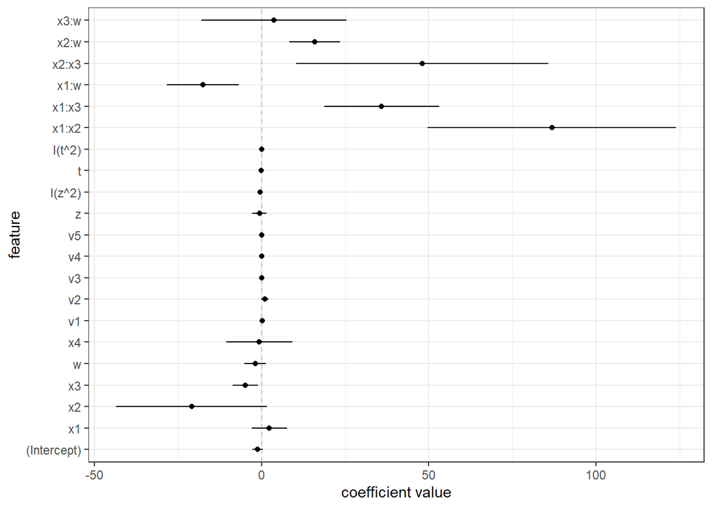

```r
viz_post_coefs_bi <- function(post_means, post_sds, xnames)
{
  tibble::tibble(
    mu = post_means,
    sd = post_sds,
    x = xnames
  ) %>%
    mutate(x = factor(x, levels = xnames)) %>%
    ggplot(mapping = aes(x = x)) +
    geom_hline(yintercept = 0, color = 'grey', linetype = 'dashed') +
    geom_point(mapping = aes(y = mu)) +
    geom_linerange(mapping = aes(ymin = mu - 2 * sd,
                                 ymax = mu + 2 * sd,
                                 group = x)) +
    labs(x = 'feature', y = 'coefficient value') +
    coord_flip() +
    theme_bw()
}

viz_post_coefs_bi(laplace_H$mode[1:ncol(Xmat_H)],
               sqrt(diag(laplace_H$var_matrix)[1:ncol(Xmat_H)]),
               colnames(Xmat_H))
```

## Linear model predictions

We use the same grid from Part2.

```r
generate_glm_post_samples <- function(mvn_result, num_samples)
{
  # specify the number of unknown beta parameters
  length_beta <- length(mvn_result$mode)

  # generate the random samples
  beta_samples <- MASS::mvrnorm(n = num_samples,
                                mu = mvn_result$mode,
                                Sigma = mvn_result$var_matrix)

  # change the data type and name
  beta_samples %>%
    as.data.frame() %>% tibble::as_tibble() %>%
    purrr::set_names(sprintf("beta_%02d", (1:length_beta) - 1))
}
```

```r
post_logistic_pred_samples <- function(Xnew, Bmat)
{
  # calculate the linear predictor at all prediction points and posterior samples
  eta_mat <- Xnew %*% t(Bmat)

  # calculate the event probability
  mu_mat <- boot::inv.logit(eta_mat)

  # book keeping
  list(eta_mat = eta_mat, mu_mat = mu_mat)
}
```

```r
summarize_logistic_pred_from_laplace <- function(mvn_result, Xtest, num_samples)
{
  # generate posterior samples of the beta parameters
  betas <- generate_glm_post_samples(mvn_result, num_samples)

  # data type conversion
  betas <- as.matrix(betas)

  # make posterior predictions on the test set
  pred_test <- post_logistic_pred_samples(Xtest, betas)

  # calculate summary statistics on the posterior predicted probability
  # summarize over the posterior samples

  # posterior mean, should you summarize along rows (rowMeans) or
  # summarize down columns (colMeans) ???
  mu_avg <- rowMeans(pred_test$mu_mat)

  # posterior quantiles
  mu_q05 <- apply(pred_test$mu_mat, 1, stats::quantile, probs = 0.05)
  mu_q95 <- apply(pred_test$mu_mat, 1, stats::quantile, probs = 0.95)

  # book keeping
  tibble::tibble(
    mu_avg = mu_avg,
    mu_q05 = mu_q05,
    mu_q95 = mu_q95
  ) %>%
    tibble::rowid_to_column("pred_id")
}
```

```r
Xviz_H <- model.matrix( ~ (x1 + x2 + x3 + w) * (x1 + x2 + x3 + w) + x4 + v1 + v2 + v3 + v4 + v5 + z + I(z^2) + t + I(t^2), data = viz_grid)
Xviz_F <- model.matrix( ~ (x1 + x2 + x3 + x4 + v1 + v2 + v3 + v4 + v5 + w + z + t) * (x1 + x2 + x3 + x4 + v1 + v2 + v3 + v4 + v5 + w + z + t), data = viz_grid)
```

```r
set.seed(2022)
post_pred_summary_H <- summarize_logistic_pred_from_laplace(laplace_H, Xviz_H, 2500)

post_pred_summary_F <- summarize_logistic_pred_from_laplace(laplace_F, Xviz_F, 2500)
```

```r
viz_bayes_logpost_preds <- function(post_pred_summary, input_df)
{
  post_pred_summary %>%
    left_join(input_df %>% tibble::rowid_to_column('pred_id'),
              by = 'pred_id') %>%
    ggplot(mapping = aes(x = x1)) +
    geom_ribbon(mapping = aes(ymin = mu_q05,
                              ymax = mu_q95,
                              group = w),
                alpha = 0.25) +
    geom_line(mapping = aes(y = mu_avg,
                            group = w),
              linewidth = 1.15) +
    facet_wrap( ~ w, labeller = 'label_both') +
    labs(y = "event probability") +
    theme_bw()
}
```

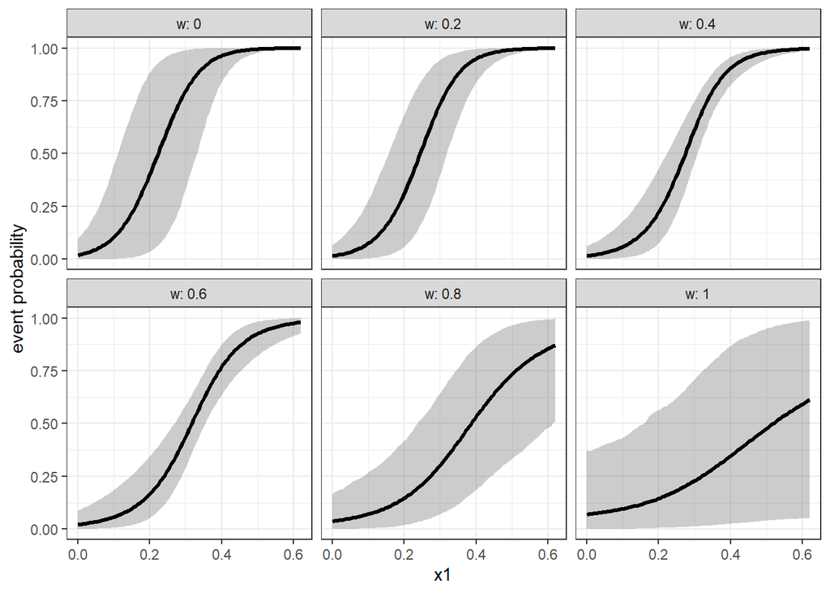

```r
viz_bayes_logpost_preds(post_pred_summary_H, viz_grid)
```

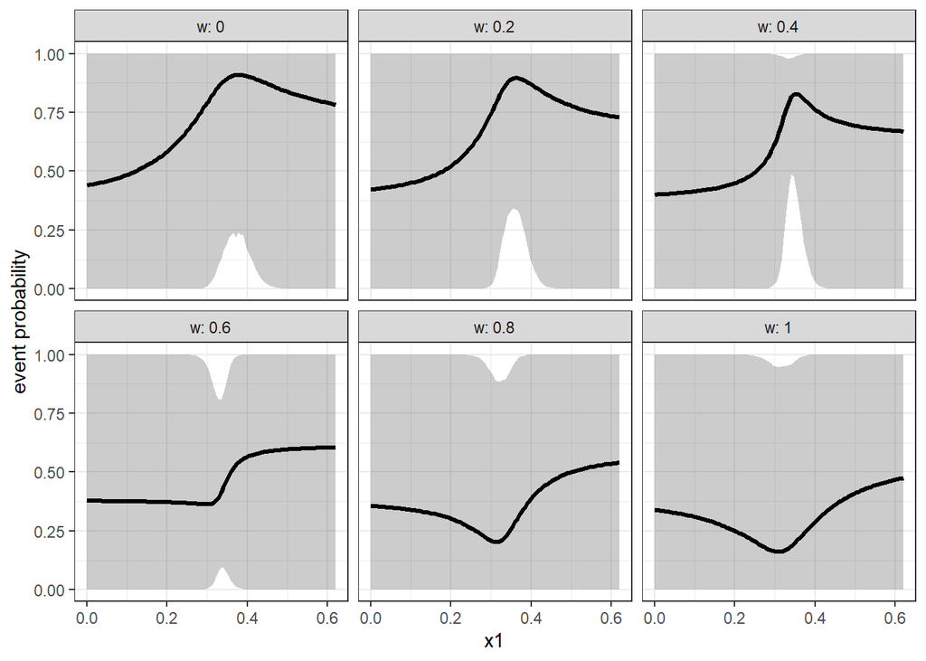

```r
viz_bayes_logpost_preds(post_pred_summary_F, viz_grid)
```

The trends are not the same for these 2 selected models.

## Train/Tune with resampling

We use the same 5 fold cross-validation with 5 repeats to train the linear models as Part 2. And we use `Accuracy` as the metric.

```r
my_ctrl <- trainControl(method = 'repeatedcv', number = 5, repeats = 5)
my_metric_bi <- 'Accuracy'
```

### Regularized regression with elastic net

In the first model, we interact the categorical variable with all pair wise interactions of the continuous features.

```r
set.seed(2022)
train(outcome ~ m * (x1 + x2 + x3 + x4 + v1 + v2 + v3 + v4 + v5) * (x1 + x2 + x3 + x4 + v1 + v2 + v3 + v4 + v5), data = df_derived,
    method = 'glmnet',
    metric = my_metric_bi,
    preProcess = c("center", "scale"),
    trControl = my_ctrl) %>% readr::write_rds("elastic_net_bi_01_model.rds")
```

In the second model, we use `mod_F`.

```r
set.seed(2022)
train(outcome ~ (x1 + x2 + x3 + x4 + v1 + v2 + v3 + v4 + v5 + w + z + t) * (x1 + x2 + x3 + x4 + v1 + v2 + v3 + v4 + v5 + w + z + t), data = df_derived,
    method = 'glmnet',
    metric = my_metric_bi,
    preProcess = c("center", "scale"),
    trControl = my_ctrl) %>% readr::write_rds("elastic_net_bi_02_model.rds")
```

In the third model, we add the categorical features to `mod_H`.

```r
set.seed(2022)
train(outcome ~ m * ((x1 + x2 + x3 + w) * (x1 + x2 + x3 + w) + x4 + v1 + v2 + v3 + v4 + v5 + z + I(z^2) + t + I(t^2)), data = df_derived,
    method = 'glmnet',
    metric = my_metric_bi,
    preProcess = c("center", "scale"),
    trControl = my_ctrl) %>% readr::write_rds("elastic_net_bi_03_model.rds")
```

```r
enet_bi_01 <- readr::read_rds("elastic_net_bi_01_model.rds")
enet_bi_02 <- readr::read_rds("elastic_net_bi_02_model.rds")
enet_bi_03 <- readr::read_rds("elastic_net_bi_03_model.rds")
```

### Neural network

In the first model, we use the interaction of the categorical input with all base continuous inputs.

```r
set.seed(2022)
train(outcome ~ m * (x1 + x2 + x3 + x4 + v1 + v2 + v3 + v4 + v5),
      data = df_derived,
      method = 'nnet',
      metric = my_metric_bi,
      preProcess = c("center", "scale"),
      trControl = my_ctrl,
      trace = FALSE) %>% readr::write_rds("neural_net_bi_01_model.rds")
```

In the second model, we add the categorical features to `mod_H`.

```r
set.seed(2022)
train(outcome ~ m * ((x1 + x2 + x3 + w) * (x1 + x2 + x3 + w) + x4 + v1 + v2 + v3 + v4 + v5 + z + I(z^2) + t + I(t^2)),
      data = df_derived,
      method = 'nnet',
      metric = my_metric_bi,
      preProcess = c("center", "scale"),
      trControl = my_ctrl,
      trace = FALSE) %>% readr::write_rds("neural_net_bi_02_model.rds")
```

```r
nnet_bi_01 <- readr::read_rds("neural_net_bi_01_model.rds")
nnet_bi_02 <- readr::read_rds("neural_net_bi_02_model.rds")
```

### Random forest

In the first model, we use the interaction of the categorical input with all base continuous inputs.

```r
set.seed(2022)
train(outcome ~ m * (x1 + x2 + x3 + x4 + v1 + v2 + v3 + v4 + v5),
      data = df_derived,
      method = 'rf',
      metric = my_metric_bi,
      trControl = my_ctrl,
      importance=TRUE) %>% readr::write_rds("rf_bi_01_model.rds")
```

In the second model, we add the categorical features to `mod_H`.

```r
set.seed(2022)
train(outcome ~ m * ((x1 + x2 + x3 + w) * (x1 + x2 + x3 + w) + x4 + v1 + v2 + v3 + v4 + v5 + z + I(z^2) + t + I(t^2)),
      data = df_derived,
      method = 'rf',
      metric = my_metric_bi,
      trControl = my_ctrl,
      importance=TRUE) %>% readr::write_rds("rf_bi_02_model.rds")
```

```r
r_forest_bi_01 <- readr::read_rds("rf_bi_01_model.rds")
r_forest_bi_02 <- readr::read_rds("rf_bi_02_model.rds")
```

### Gradient boosted tree

In the first model, we use the interaction of the categorical input with all base continuous inputs.

```r
set.seed(2022)
train(outcome ~ m * (x1 + x2 + x3 + x4 + v1 + v2 + v3 + v4 + v5),
      data = df_derived,
      method = 'xgbTree',
      metric = my_metric_bi,
      trControl = my_ctrl,
      verbosity = 0) %>% readr::write_rds("boosted_tree_bi_01_model.rds")
```

In the second model, we use the setting in `mod_H`.

```r
set.seed(2022)
train(outcome ~ (x1 + x2 + x3 + w) * (x1 + x2 + x3 + w) + x4 + v1 + v2 + v3 + v4 + v5 + z + I(z^2) + t + I(t^2),
      data = df_derived,
      method = 'xgbTree',
      metric = my_metric_bi,
      trControl = my_ctrl,
      verbosity = 0) %>% readr::write_rds("boosted_tree_bi_02_model.rds")
```

```r
xgb_bi_01 <- readr::read_rds("boosted_tree_bi_01_model.rds")
xgb_bi_02 <- readr::read_rds("boosted_tree_bi_02_model.rds")
```

### Support Vector Machines

We use pair wise continuous features.

```r
set.seed(2022)
train(outcome ~ (x1 + x2 + x3 + x4 + v1 + v2 + v3 + v4 + v5 + w + z + t) * (x1 + x2 + x3 + x4 + v1 + v2 + v3 + v4 + v5 + w + z + t),
      data = df_derived,
      method = "svmLinear",
      preProcess = c("center", "scale"),
      trControl = my_ctrl) %>% readr::write_rds("support_vector_bi_model.rds")
```

```r
svm_bi <- readr::read_rds("support_vector_bi_model.rds")
```

### Multivariate Additive Regression Splines

We add the categorical features to `mod_H`.

```r
set.seed(2022)
train(outcome ~ m * (x1 + x2 + x3 + w) * (x1 + x2 + x3 + w) + x4 + v1 + v2 + v3 + v4 + v5 + z + I(z^2) + t + I(t^2),
      data = df_derived,
      method = 'earth',
      metric = my_metric_bi,
      trControl = my_ctrl) %>% readr::write_rds("mars_bi_model.rds")
```

```r
mars_bi <- readr::read_rds("mars_bi_model.rds")
```

### Identify the best model

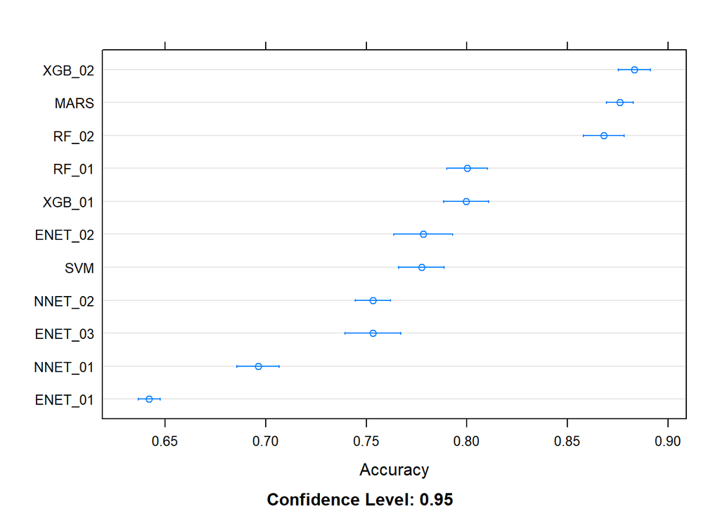

```r
caret_Accuracy_compare <- resamples(list(ENET_01 = enet_bi_01,
                                     ENET_02 = enet_bi_02,
                                     ENET_03 = enet_bi_03,
                                     NNET_01 = nnet_bi_01,
                                     NNET_02 = nnet_bi_02,
                                     RF_01 = r_forest_bi_01,
                                     RF_02 = r_forest_bi_02,
                                     XGB_01 = xgb_bi_01,
                                     XGB_02 = xgb_bi_02,
                                     SVM = svm_bi,
                                     MARS = mars_bi))
dotplot(caret_Accuracy_compare, metric = 'Accuracy')
```

We can see the `xgb_bi_02` is the best model we have.